# Explorative Datenanalyse in R - Finale Abgabe

Sophie-Marianna Sloboda, Stefanie Arndt

2023-08-27

# Einleitung

Im Folgenden wird eine explorative Datenanalyse vorgenommen, um auf die Verdienstunterschiede zwischen Frauen und Männern hinzuweisen.

## Zentrale Fragestellung der Datenanalyse

Die im Fokus stehende Fragestellung bezieht sich darauf, ob Frauen weniger verdienen als Männer und welche Erklärungen es dafür geben könnte. Zunächst soll geklärt werden, ob Frauen weniger als Männer verdienen, weil sie weniger Stunden pro Woche arbeiten. Zudem wird der Verdienst von in Vollzeit arbeitenden Frauen und Männern verglichen. Des Weiteren soll aufgezeigt werden, inwiefern sich der Verdienst nach Geschlecht in verschiedenen Wirtschaftszweigen unterscheidet. Da es keinen gesetzlich definierten Stundensatz für die Vollzeitarbeit gibt, wird im Verlauf der Arbeit der wöchentliche Stundensatz von mindestens 35 Stunden pro Woche als Vollzeit verstanden.

# Datenmanagement

## Datenquelle

Die Verdienststrukturerhebung (VSE) ist aus dem Jahr 2018. Herausgeber sind die Statistischen Ämter des Bundes und der Länder. Die VSE enthält vollständig anonymisierte Daten und besteht aus Betriebs- und Arbeitnehmerdatensätzen, die miteinander verknüpft sind.Die Daten eignen sich gut zur Analyse geschlechtsspezifischer Lohnunterschiede. Da die Stichprobe auf Bundeslandebene erfolgt und die regionale Angabe für das Campus File stark aggregiert wird, lassen sich für regionale Gliederungen keine repräsentativen Ergebnisse erzielen. Die Statistik enthält mitunter Merkmale zur Person (Geschlecht, Alter, Ausbildung), zur Tätigkeit (Berufsgruppenschlüssel der Sozialversicherung, Stellung im Beruf, Leistungsgruppe, Arbeitszeit, Dauer der Betriebszugehörigkeit) und zum Verdienst (Brutto, Netto, Gesamtverdienst für Überstunden, Zulagen für Schicht-/Nachtarbeit, Sonderzahlungen, Lohnsteuer, Sozialabgaben)

## Import und Einlesen der Datensätze

Die Daten wurden zunächst heruntergeladen und lokal zwischengespeichert. Zum Einlesen wurde der Befehl “read_csv()” ausgeführt. Für ein vereinfachtes Vorgehen wurde dem eingelesenen Datensatz “CAMPUS-File_VSE_2018_Arbeitnehmer.csv” die Bezeichnung “datenverdienst” zugeordnet.

### Strukturdaten

Die Strukturdaten zeigen, dass der Datensatz insgesamt 14.014 Beobachtungen und 34 Variablen umfasst. Von den Beobachtungen lassen sich 7626 dem männlichen Geschlecht zuordnen und 6388 dem weiblichen Geschlecht. Diverse Geschlechtsbezeichnungen werden in diesem Datensatz nicht aufgeführt.

```r
datenverdienst <- read_csv("C:/Users/sunny/OneDrive/Desktop/sophies_stuff/sose_23/dvv_ds/CAMPUS-File_VSE_2018_Arbeitnehmer.csv")
dim(datenverdienst)
```

```
## [1] 14014    34
```

```r
table(datenverdienst$ef10)
```

```
##
##    1    2
## 7626 6388
```

### Erste Anpassungen von Variablen und Erstellung von Kontingenztabellen

```r
datenverdienst$ef10 <- as.factor(datenverdienst$ef10)

colnames(datenverdienst)[colnames(datenverdienst) == "ef10"] <- "Geschlecht"

colnames(datenverdienst)[colnames(datenverdienst) == "ef4"] <- "Wirtschaftszweig"
```

# Explorative Datenanalyse

## Weitere Betrachtung einzelner Variablen

Da es sich bei der explorativen Datenanalyse um einen iterativen Prozess handelt, werden immer wieder die Daten aufbereitet und angepasst. Zusätzlich werden Subsets des Datensatzes erstellt, um Auffälligkeiten in den Daten schneller und fokussierter zu identifizieren.

Das Subset wochenstunden_ab40 dient zur genaueren Betrachtung der wöchentlichen Arbeitszeit der Geschlechter.

```r
colnames(datenverdienst)[colnames(datenverdienst) == "ef16u2"] <- "Ausbildung"

colnames(datenverdienst)[colnames(datenverdienst) == "ef18"] <- "wochenstunden"
```

```r
#subset - Wochenstunden >= 40

wochenstunden_ab40 <- datenverdienst[datenverdienst$wochenstunden >= 40, c("Geschlecht", "wochenstunden")]
view(wochenstunden_ab40)

table(wochenstunden_ab40$Geschlecht, wochenstunden_ab40$wochenstunden)
```

```
##
##       40   41   42   43   44   45
##   1 3031  786   54    8   11  126
##   2 1531  161   18    8    3   23
```

```r
# Subset - Wochenstunden >= 40
wochenstunden_ab40 <- datenverdienst[datenverdienst$wochenstunden >= 40, c("Geschlecht", "wochenstunden")]

# Anzahl der Männer im Subset wochenstunden_ab40
anzahl_maenner_ab40 <- sum(wochenstunden_ab40$Geschlecht == 1)

# Anzahl der Frauen im Subset wochenstunden_ab40
anzahl_frauen_ab40 <- sum(wochenstunden_ab40$Geschlecht == 2)

# Gesamtanzahl der Personen in der Gesamtstichprobe
gesamtanzahl_personen <- nrow(datenverdienst)

# Prozentsatz der Männer im Subset ab_40
prozentsatz_maenner_ab40 <- (anzahl_maenner_ab40 / gesamtanzahl_personen) * 100

# Prozentsatz der Frauen im Subset ab_40
prozentsatz_frauen_ab40 <- (anzahl_frauen_ab40 / gesamtanzahl_personen) * 100
```

## Unterscheidung der Geschlechter in den Visualisierungen

1 entspricht dem Geschlecht “Männlich”. 2 entspricht dem Geschlecht “Weiblich”. Dies gilt für alle Visualisierungen, soweit dies nicht bereits in der Legende vermerkt ist.

## Geschlechterverteilung bei einem Wochenstundensatz von mindestens 40 Stunden

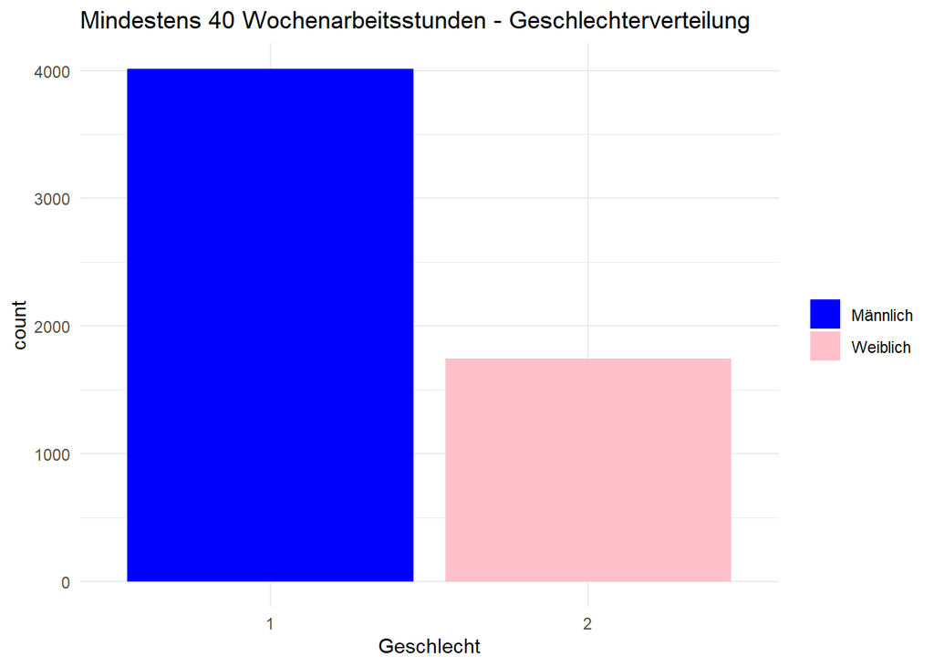

```r
# Plot für Geschlechterverteilung bei mindestens 40 Wochenarbeitsstunden
ggplot(data = wochenstunden_ab40, aes(x = Geschlecht, fill = factor(Geschlecht))) +
  geom_bar() +
  labs(title = "Mindestens 40 Wochenarbeitsstunden - Geschlechterverteilung",
       x = "Geschlecht") +
  scale_fill_manual(values = c("1" = "blue", "2" = "pink"),
                    labels = c("Männlich", "Weiblich")) +
  theme_minimal() +
  theme(legend.title = element_blank()) +
  guides(fill = guide_legend(title = "Geschlecht"))
```

Im ersten Schritt wurde das Verhältnis der in Vollzeit arbeitenden Männer und Frauen ermittelt. Die vorliegende Grafik zeigt die Anzahl von Männern (1) und Frauen (2) mit einer Wochenstundenanzahl von mindestens 40 Stunden. Dabei ist festzustellen, dass die Anzahl der Männer, die in Vollzeit arbeiten, mehr als doppelt so hoch sind, als die Anzahl der Frauen. Konkret sind es 4016 Männer und 1744 Frauen. Daraufhin lässt sich schlussfolgern, dass dies ein erster Indiz sein kann, weshalb Frauen weniger verdienen als Männer. Im weiteren Verlauf der Datenanalyse werden mindestens, sowie genau 35 Stunden für den Vergleich herangezogen.

## Geschlechterverteilung nach Ausbildungsabschluss

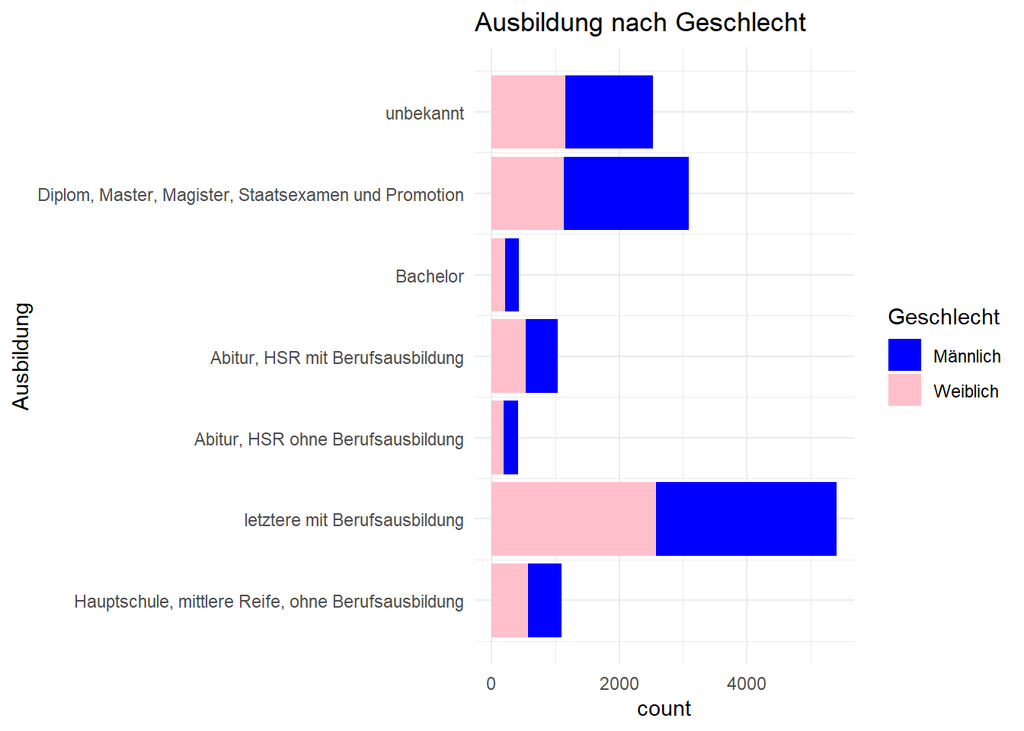

```r
ggplot(data = datenverdienst) +
  stat_count(mapping = aes(x = Ausbildung, fill = Geschlecht)) +
  scale_x_continuous(
    breaks = c(1:7),
    labels = c("Hauptschule, mittlere Reife, ohne Berufsausbildung",
               "letztere mit Berufsausbildung",
               "Abitur, HSR ohne Berufsausbildung",
               "Abitur, HSR mit Berufsausbildung",
               "Bachelor",
               "Diplom, Master, Magister, Staatsexamen und Promotion",
               "unbekannt")


  ) +
theme(axis.text.y = element_text(angle = 0, hjust = 1)) +
  coord_flip() +

  labs(title = "Ausbildung nach Geschlecht") +
  scale_fill_manual(values = c("1" = "blue", "2" = "pink"),
                    labels = c("Männlich", "Weiblich")) +
   theme_minimal() +
  guides(fill = guide_legend(title = "Geschlecht"))
```

Die Abbildung zeigt den Ausbildungsstand von Frauen und Männern. Sie dient zur weiteren Untersuchung der Verdienstunterschiede. Die Verteilung auf die einzelnen Kategorien ist paritätisch. Werden sich die Kategorien „abgeschlossene Berufsausbildung und Bachelor“ näher angesehen, ist auch in diesen Gruppen eine gleichmäßige Verteilung zu verzeichnen. Die höchste zahlenmäßige Abweichung lässt sich beim Diplom, Master, Magister, Staatsexamen und Promotion feststellen. Der Männeranteil ist in dieser Kategorie höher. Es könnte vermutet werden, dass dies einen Einfluss auf das Gehalt haben könnte. Allerdings ist die Stichprobe dafür nicht repräsentativ genug.

## Untersuchung von Unterschieden der Geschlechter in Bezug auf den Bruttomonatsverdienst und Bruttojahresverdienst

ef21 = Bruttomonatsverdienst insgesamt

ef27 = Bruttojahresverdienst insgesamt

Die Mittelwerte und Mediane für den Bruttoverdienst im Jahr sowie Monat zeigen, dass Männer mehr als Frauen verdienen. Hier wird die Wochenstundenanzahl allerdings nicht berücksichtigt.

```r
mean_gender_by_month1 <- aggregate(ef21 ~ Geschlecht, data = datenverdienst , FUN = mean)

mean_gender_by_month1
```

```
##   Geschlecht     ef21
## 1          1 3428.907
## 2          2 2289.892
```

```r
mean_gender_by_year1 <- aggregate(ef27 ~ Geschlecht, data = datenverdienst, FUN = mean)
mean_gender_by_year1
```

```
##   Geschlecht     ef27
## 1          1 42082.43
## 2          2 28305.66
```

```r
median_gender_by_month2 <- aggregate(ef21 ~ Geschlecht, data = datenverdienst , FUN = median)

median_gender_by_month2
```

```
##   Geschlecht ef21
## 1          1 3154
## 2          2 2057
```

```r
median_gender_by_year2 <- aggregate(ef27 ~ Geschlecht, data = datenverdienst, FUN = median)
median_gender_by_year2
```

```
##   Geschlecht    ef27
## 1          1 39254.5
## 2          2 25147.0
```

### Boxplots zum Bruttojahresverdienst und Bruttomonatsverdienst

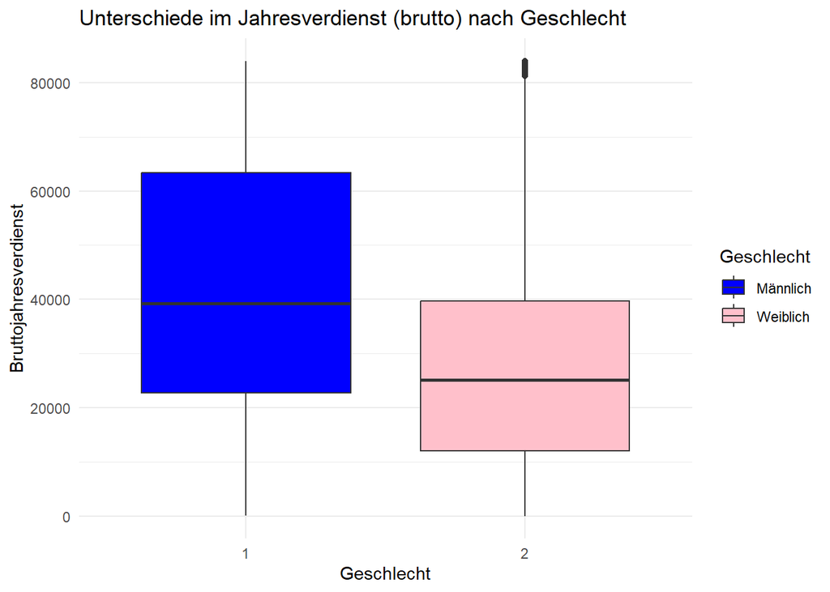

```r
#boxplot brutto jahresverdienst, m/w

ggplot(datenverdienst, aes(x = factor(Geschlecht), y = ef27, fill = Geschlecht)) +
  geom_boxplot() +
  xlab("Geschlecht") +
  ylab("Bruttojahresverdienst") +
  ggtitle("Unterschiede im Jahresverdienst (brutto) nach Geschlecht") +
  scale_fill_manual(values = c("1" = "blue", "2" = "pink"),
                    labels = c("Männlich", "Weiblich")) +
  theme_minimal() +
  guides(fill = guide_legend(title = "Geschlecht", labels = c("Männlich", "Weiblich")))
```

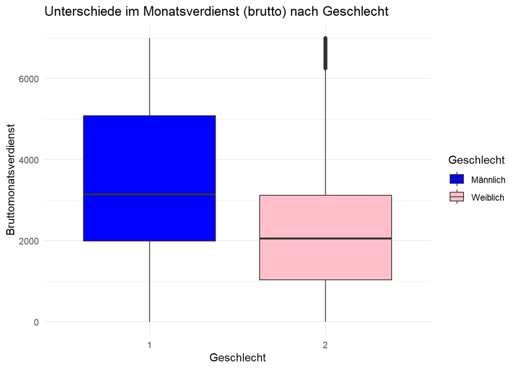

```r
#boxplot brutto monatsverdienst, m/w

ggplot(datenverdienst, aes(x = factor(Geschlecht), y = ef21, fill = Geschlecht)) +
  geom_boxplot() +
  xlab("Geschlecht") +
  ylab("Bruttomonatsverdienst") +
  ggtitle("Unterschiede im Monatsverdienst (brutto) nach Geschlecht")  +
  scale_fill_manual(values = c("1" = "blue", "2" = "pink"),
                    labels = c("Männlich", "Weiblich")) +
  theme_minimal() +
  guides(fill = guide_legend(title = "Geschlecht", labels = c("Männlich", "Weiblich")))
```

```r
#Ausreisser bei Geschlecht Weiblich ermitteln

ausreisser_2_bjv <- datenverdienst[datenverdienst$Geschlecht == "2", ]

ausreisser_anzahl <- length(boxplot.stats(ausreisser_2_bjv$ef27)$out)

print(ausreisser_anzahl)
```

```
## [1] 153
```

Beide Boxplots bestätigen, dass Frauen weniger als Männer verdienen. Der Bruttoverdienst ist hier noch unabhängig von der Wochenarbeitszeit. Daher ist die Begründung vermutlich, dass Frauen in erster Linie weniger Wochenstunden arbeiten als Männer. Beide Boxplots zeigen, dass es unter den Frauen Ausreißer gibt. Dies zeigt, dass Frauen eher in Teilzeit als in Vollzeit arbeiten und Frauen, die in Vollzeit arbeiten nicht zwangsläufig weniger als Männer verdienen. Daraus ergibt sich die These, dass die geschlecherspezifischen Gehaltsunterschiede auch mit der Wahl des Wirtschaftszweiges zu begründen sind.

## Vertretung der Geschlechter in verschiedenen Wirtschaftszweigen

```r
wirtschaftszweige_geschlecht <- ggplot(data = datenverdienst,aes(x= Wirtschaftszweig,
                                                           fill = Geschlecht))
wirtschaftszweige_geschlecht <- wirtschaftszweige_geschlecht + geom_bar(stat="count",
                                                            position = position_dodge2(preserve = "single"))


wirtschaftszweige_geschlecht <- wirtschaftszweige_geschlecht + labs(title ="Verteilung der Wirtschaftszweige nach Geschlecht")
wirtschaftszweige_geschlecht <- wirtschaftszweige_geschlecht + labs(subtitle ="rot = männlich; gruen = weiblich")
```

[figure not shown]

```r
wirtschaftszweige_geschlecht <- wirtschaftszweige_geschlecht  + labs(x ="Wirtschaftszweig", y = "Count")

wirtschaftszweige_geschlecht <- wirtschaftszweige_geschlecht + scale_x_continuous(breaks = c(1:15))
#wirtschaftszweige_test <- wirtschaftszweige_test + scale_y_continuous()

wirtschaftszweige_geschlecht
```

Die vorliegende Grafik zeigt die Verteilung des Männer- und Frauenanteils in den jeweiligen Wirtschaftszweigen. Dabei ist zunächst festzustellen, dass die zahlenmäßige Verteilung auf die einzelnen Wirtschaftsbereiche stark differiert. Die Frage die sich daraus ableitet ist, ob die Auswertung auf einer repräsentativen Datenerhebung beruht, zumindest was die Auswertung pro Wirtschaftsbereich betrifft. Die Wirtschaftszweige sind nicht immer schlüssig aggregiert. Die Grafik zeigt beispielsweise, dass Frauen häufiger im Wirtschaftsbereich Handel und Kfz vertreten sind. Der Datensatz nimmt keine Differenzierung zwischen Kfz-Reparatur und -instandhaltung und dem Sektor Handel vor. Weiterhin lässt sich feststellen, dass im Wirtschaftsbereich 2 ( Bergbau und Gewinnung von Steinen und Erden, Verarbeitendes Gewerbe), 4 (Baugewerbe) und 13 (Gesundheits- und Sozialwesen) die höchsten Differenzen zwischen Männern und Frauen bestehen. In den Wirtschaftsbereichen 2 und 4 sind mehr Männer als Frauen beschäftigt und im Wirtschaftsbereich 13 sind mehr Frauen als Männer beschäftigt. Diese Aufstellung entspricht der der Annahme der Existenz von frauen- und männertypischen Berufen.

## Durchschnittlicher Bruttomonatsverdienst nach Geschlecht und Wirtschaftszweig

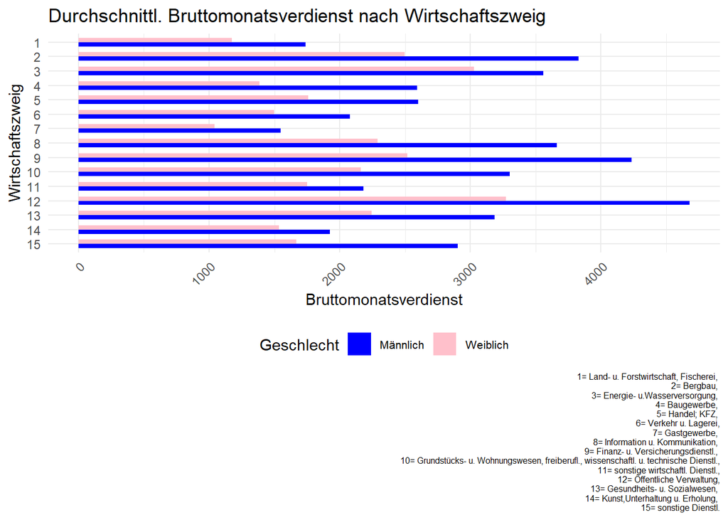

```r
#Durchschnittlichen Bruttomonatsverdienst nach Geschlecht und Wirtschaftszweig
#bar statt facet wrap ohne bestimtme stundenanzahl

# Plot für den durchschnittlichen Bruttomonatsverdienst nach Wirtschaftszweig mit Geschlecht colorfill
ggplot(brutto_month_gender_summary, aes(x = factor(Wirtschaftszweig, levels = 15:1), y = ef21, fill = factor(Geschlecht))) +
  geom_bar(stat = "summary", fun = "mean", position = "dodge", width = 0.6) +
  labs(title = "Durchschnittl. Bruttomonatsverdienst nach Wirtschaftszweig",
       x = "Wirtschaftszweig",
       y = "Bruttomonatsverdienst",
       caption ="1= Land- u. Forstwirtschaft, Fischerei,
                  2= Bergbau,
                  3= Energie- u.Wasserversorgung,
                  4= Baugewerbe,
                  5= Handel; KFZ,
                  6= Verkehr u. Lagerei,
                  7= Gastgewerbe,
                  8= Information u. Kommunikation,
                  9= Finanz- u. Versicherungsdienstl.,
                  10= Grundstücks- u. Wohnungswesen, freiberufl., wissenschaftl. u. technische Dienstl.,
                  11= sonstige wirtschaftl. Dienstl.,
                  12= Öffentliche Verwaltung,
                  13= Gesundheits- u. Sozialwesen,
                  14= Kunst,Unterhaltung u. Erholung,
                  15= sonstige Dienstl.") +
  scale_fill_manual(values = c("1" = "blue", "2" = "pink"),
                    labels = c("Männlich", "Weiblich")) +
  theme_minimal() +
  theme(axis.text.x = element_text(angle = 45, hjust = 1),
        legend.text = element_text(size = 8),
        legend.position = "bottom",
        plot.caption = element_text(size = 6)) +
  guides(fill = guide_legend(title = "Geschlecht")) +
  coord_flip()
```

Der Plot kommt ohne Berücksichtigung des Wochenstundensatzes zustande. Männer verdienen in allen 15 Wirtschaftszweigen mehr als Frauen.

## Betrachtung der Verdienstunterschiede bei in Vollzeit (mind. 35 Stdt./Woche) arbeitenden Männern und Frauen

Um Verzerrungen bei der Verdienstanalyse zu vermeiden, werden hier nur die Daten der in Vollzeit arbeitenden Männer und Frauen verglichen. Als Vollzeit wird hier ein Wochenstundensatz von mindestens 35 definiert. Um eine nuanciertere Analyse zu ermöglichen, werden zusätzlich Daten zu Arbeitnehmer/innen, die genau 35 Stunden pro Woche arbeiten, herangezogen.

```r
# Subset - mind 35h

wochenstunden_mind35 <- datenverdienst[datenverdienst$wochenstunden >= 35, c("Geschlecht", "wochenstunden")]
view(wochenstunden_mind35)
```

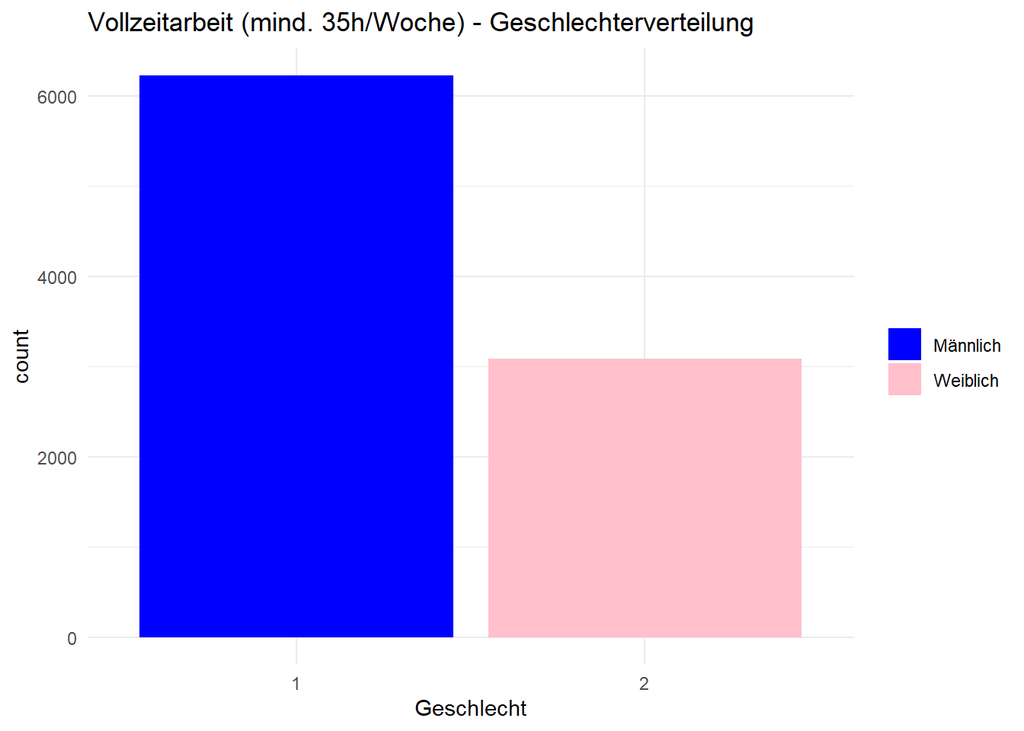

```r
#plot mind 35h
ggplot(data = wochenstunden_mind35) +
  stat_count(mapping = aes(x = Geschlecht, fill = factor(Geschlecht))) +
  labs(title = "Vollzeitarbeit (mind. 35h/Woche) - Geschlechterverteilung") +
  scale_fill_manual(values = c("1" = "blue", "2" = "pink"),
                    labels = c("Männlich", "Weiblich")) +
  theme_minimal() +
  theme(legend.title = element_blank()) +  # Entfernt Titel der Legende
  guides(fill = guide_legend(title = "Geschlecht"))
```

Es arbeiten fast doppelt so viele Männer wie Frauen mindestens 35 Stunden pro Woche.

Männer, die mindestens 35 Wochenstunden arbeiten verdienen unabhängig vom Wirtschaftszweig durchschnittlich 3962.0150931 Euro.

Bei genau 35 Stunden sind es durchschnittlich 4064.0843558 Euro.

Frauen, die mindestens 35 Wochenstunden arbeiten verdienen unabhängig vom Wirtschaftszweig durchschnittlich 3336.5980551 Euro.

Bei genau 35 Stunden sind es durchschnittlich 2857.3174603 Euro.

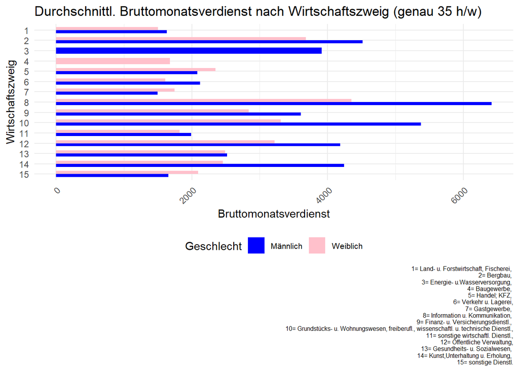

```r
# barplot

# Plot für den durchschnittlichen Bruttomonatsverdienst nach Wirtschaftszweig mit Geschlecht colorfill
ggplot(brutto_month_gender_35h, aes(x = factor(Wirtschaftszweig, levels = 15:1), y = ef21, fill = factor(Geschlecht))) +
  geom_bar(stat = "summary", fun = "mean", position = "dodge", width = 0.6) +
  labs(title = "Durchschnittl. Bruttomonatsverdienst nach Wirtschaftszweig (genau 35 h/w)",
       x = "Wirtschaftszweig",
       y = "Bruttomonatsverdienst",
       caption ="1= Land- u. Forstwirtschaft, Fischerei,
                  2= Bergbau,
                  3= Energie- u.Wasserversorgung,
                  4= Baugewerbe,
                  5= Handel; KFZ,
                  6= Verkehr u. Lagerei,
                  7= Gastgewerbe,
                  8= Information u. Kommunikation,
                  9= Finanz- u. Versicherungsdienstl.,
                  10= Grundstücks- u. Wohnungswesen, freiberufl., wissenschaftl. u. technische Dienstl.,
                  11= sonstige wirtschaftl. Dienstl.,
                  12= Öffentliche Verwaltung,
                  13= Gesundheits- u. Sozialwesen,
                  14= Kunst,Unterhaltung u. Erholung,
                  15= sonstige Dienstl.") +
  scale_fill_manual(values = c("1" = "blue", "2" = "pink"),
                    labels = c("Männlich", "Weiblich")) +
  theme_minimal() +
  theme(axis.text.x = element_text(angle = 45, hjust = 1),
        legend.text = element_text(size = 8),
        legend.position = "bottom",
        plot.caption = element_text(size = 6)) +
  guides(fill = guide_legend(title = "Geschlecht")) +
  coord_flip()
```

Für Wirtschaftszweig 3 werden lediglich Männer in der Grafik aufgezeigt, da keine der evaluierten Frauen genau 35 Stunden pro Woche arbeitet.

Für Wirtschaftszweig 4 gibt es dagegen keine Männer, die genau 35 Stunden arbeiten.

```r
# Erklärung, warum bei Wirtschaftszweig 4 kein Datenpunkt für Männer

durchschnitt_gehalt_m_35h_zweig4 <- mean(brutto_month_gender_35h$ef21[brutto_month_gender_35h$Geschlecht == "1" & brutto_month_gender_35h$Wirtschaftszweig == 4])
durchschnitt_gehalt_m_35h_zweig4
```

```
## [1] NaN
```

```r
# mind 35h

brutto_month_gender_mind_35h <- datenverdienst %>%
  filter(wochenstunden >= 35)
```

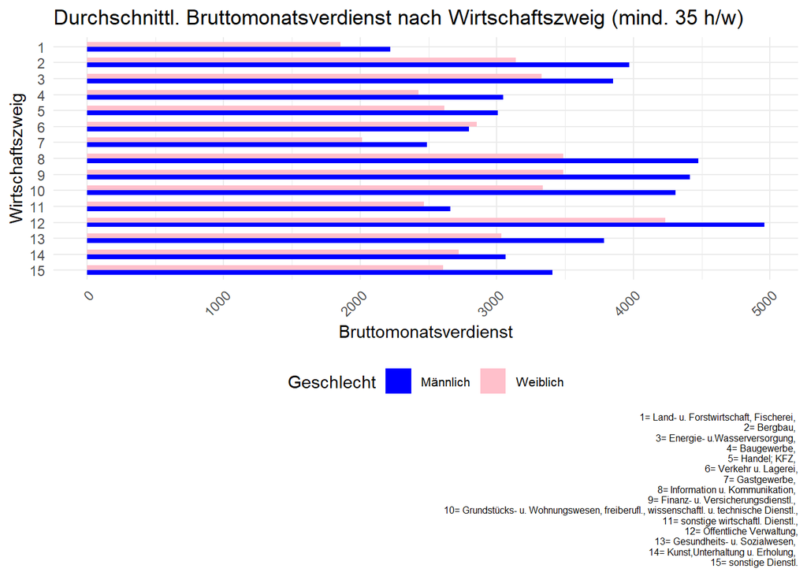

```r
# Plot für durchschnittlichen Bruttomonatsverdienst nach Wirtschaftszweig mit Geschlecht als Einfärbung
ggplot(brutto_month_gender_mind_35h, aes(x = factor(Wirtschaftszweig, levels = 15:1), y = ef21, fill = factor(Geschlecht))) +
  geom_bar(stat = "summary", fun = "mean", position = "dodge", width = 0.6) +
  labs(title = "Durchschnittl. Bruttomonatsverdienst nach Wirtschaftszweig (mind. 35 h/w)",
       x = "Wirtschaftszweig",
       y = "Bruttomonatsverdienst",
       caption ="1= Land- u. Forstwirtschaft, Fischerei,
                  2= Bergbau,
                  3= Energie- u.Wasserversorgung,
                  4= Baugewerbe,
                  5= Handel; KFZ,
                  6= Verkehr u. Lagerei,
                  7= Gastgewerbe,
                  8= Information u. Kommunikation,
                  9= Finanz- u. Versicherungsdienstl.,
                  10= Grundstücks- u. Wohnungswesen, freiberufl., wissenschaftl. u. technische Dienstl.,
                  11= sonstige wirtschaftl. Dienstl.,
                  12= Öffentliche Verwaltung,
                  13= Gesundheits- u. Sozialwesen,
                  14= Kunst,Unterhaltung u. Erholung,
                  15= sonstige Dienstl.") +
  scale_fill_manual(values = c("1" = "blue", "2" = "pink"),
                    labels = c("Männlich", "Weiblich")) +
  theme_minimal() +
  theme(axis.text.x = element_text(angle = 45, hjust = 1),
        legend.text = element_text(size = 8),
        legend.position = "bottom",
        plot.caption = element_text(size = 6)) +
  guides(fill = guide_legend(title = "Geschlecht")) +
  coord_flip()
```

Im weiteren Verlauf der Analyse soll geklärt werden, ob Frauen in Wirtschaftszweigen arbeiten, in denen durchschnittlich weniger verdient wird.

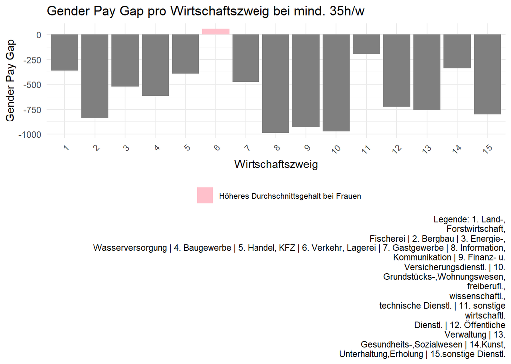

```r
# barchart Gender Pay Gap-Differenzen pro Wirtschaftszweig
ggplot(combined_mean, aes(x = factor(Wirtschaftszweig), y = mean_difference, fill = factor(Wirtschaftszweig))) +
  geom_bar(stat = "identity", position = "dodge") +
  labs(title = "Gender Pay Gap pro Wirtschaftszweig bei mind. 35h/w",
       x = "Wirtschaftszweig",
       y = "Gender Pay Gap") +
  scale_x_discrete(labels = combined_mean$Wirtschaftszweig, breaks = 1:15) +
  scale_fill_manual(values = c("6" = "pink", "default" = "blue"),
                    labels = c("Höheres Durchschnittsgehalt bei Frauen", "")) +
  theme_minimal() +
  theme(axis.text.x = element_text(angle = 45, hjust = 1),
        legend.text = element_text(size = 8),
        legend.position = "bottom") +
  guides(fill = guide_legend(title = NULL)) +
  labs(caption = paste("Legende:", paste(wrapped_labels, collapse = " | ")))
```

Die Grafik zeigt den Gender Pay Gap (ausgedrückt in Euro) bei Männern und Frauen mit einem Wochenstundensatz von mind. 35h/Woche. Bis auf Wirtschaftszweig 6 (Verkehr und Lagerei) verfügen Männer über ein höheres monatliches Bruttodurschnittsgehalt. Männer verdienen hier teilweise bis nahezu 1000 Euro mehr im Monat als Frauen. Am höchsten ist der Gender Pay Gap in den Wirtschaftszweigen 2 (Bergbau), 8 (Information, Kommunikation), 9 (Finanz- u. Versicherungsdienstl.), 10 (Grundstücks-,Wohnungswesen, freiberufl., wissenschaftl., technische Dienstl.)

Es soll beantwortet werden, ob Frauen eher in Berufen arbeiten, in denen generell weniger verdient wird: Wie zuvor in der Grafik “Durchschnittl. Bruttomonatsverdienst nach Wirtschaftszweig” errechnet wurde, verdienen Männer sowie Frauen am wenigsten im Wirtschaftszweig 7 (Gastgewerbe), 1 (Land u. Forstwirtschaft, Fischerei).

Der Gender Pay Gap zeigt jedoch in allen Wirtschaftszweigen mit Ausnahme des Wirtschaftszweiges 6 (Verkehr und Lagerei), dass Männer mehr verdienen. Dadurch, dass fast jeder Wirtschaftszweig eine deuliche Diskrepanz aufweist, kann die Berufswahl von Frauen nicht als Argument für einen niedrigeren Bruttomonatsverdienst geschlussfolgert werden.

# Fazit

Die Datenanalyse zeigt, dass deutlich mehr Männer in Vollzeit arbeiten als Frauen. Vergleicht man den Verdienst der ausschließlich in Vollzeit arbeitenden Männer und Frauen, verdienen Männer allerdings auch mehr. Bei einem Arbeitswochenstundensatz von genau 35 Stunden sieht man eine weitaus größere Diskrepanz in puncto Bruttomonatsverdienst zwischen den Geschlechtern. Um den Zusammenhang dieser Ergebnisse mit den Wirtschaftszweigen aufzuzeigen, wurde analysiert, welche Wirtschaftszweige männerdominierend und welche frauendominierend sind. Die Berufswahl ist anhand der Ergebnisse der Analyse kein ausschlaggebendes Argument dafür, dass Frauen weniger verdienen.

Indem ausschließlich in Vollzeit arbeitende Männer und Frauen gegenübergestellt wurden und der Gender Pay Gap in 14 von 15 Wirtschaftszweigen sichtbar groß ist, vermuten wir, dass gesellschaftliche Aspekte einen großen Einfluss auf die Verdienstunterschiede nehmen. Diese lassen sich anhand des vorhandenen Datensatzes jedoch nicht eindeutig erfassen.

Zusätzlich lässt sich wiederholt sagen, dass die Wirtschaftszweige unserer Auffassung nach nicht immer schlüssig aggregiert wurden (z.B. Wirtschaftszweig 5: „Handel; Instandhaltung von Kraftfahrzeugen“) und eine genauere Analyse des Einflusses der Berufswahl dadurch erschwert wird.